# ggmap: Spatial Visualization with ggplot2

David Kahle

Baylor University

Hadley Wickham

Rice University

2013-06-02

Abstract

In spatial statistics the ability to visualize data and models superimposed with their basic social landmarks and geographic context is invaluable. *ggmap* is a new tool which enables such visualization by combining the spatial information of static maps from Google Maps, OpenStreetMap, Stamen Maps or CloudMade Maps with the layered grammar of graphics implementation of *ggplot2*. In addition, several new utility functions are introduced which allow the user to access the Google Geocoding, Distance Matrix, and Directions APIs. The result is an easy, consistent and modular framework for spatial graphics with several convenient tools for spatial data analysis.

# Introduction

Visualizing spatial data in R can be a challenging task. Fortunately the task is made a good deal easier by the data structures and plot methods of [*sp*](https://CRAN.R-project.org/package=sp), [*RgoogleMaps*](https://CRAN.R-project.org/package=RgoogleMaps), and related packages (Pebesma and Bivand 2006; R. S. Bivand, Pebesma, and Rubio 2008; Loecher and Berlin School of Economics and Law 2013). Using those methods, one can plot the basic geographic information of (for instance) a shape file containing polygons for areal data or points for point referenced data. However, compared to specialized geographic information systems (GISs) such as ESRI’s ArcGIS, which can plot points, polygons, etc. on top of maps and satellite imagery with drag-down menus, these visualizations can be pretty disappointing. This article details some new methods for the visualization of spatial data in R using the layered grammar of graphics implementation of [*ggplot2*](https://CRAN.R-project.org/package=ggplot2) in conjunction with the contextual information of static maps from Google Maps, OpenStreetMap, Stamen Maps or CloudMade Maps (H. Wickham 2009, 2010). The result is an easy to use R package named [*ggmap*](https://CRAN.R-project.org/package=ggmap). After describing the nuts and bolts of *ggmap*, we showcase some of its capabilities in a simple case study concerning violent crimes in downtown Houston, Texas and present an overview of a few utility functions.

# Plotting spatial data in R

Areal data is data which corresponds to geographical extents with polygonal boundaries. A typical example is the number of residents per zip code. Considering only the boundaries of the areal units, we are used to seeing areal plots in R which resemble those in Figure 1 (left).

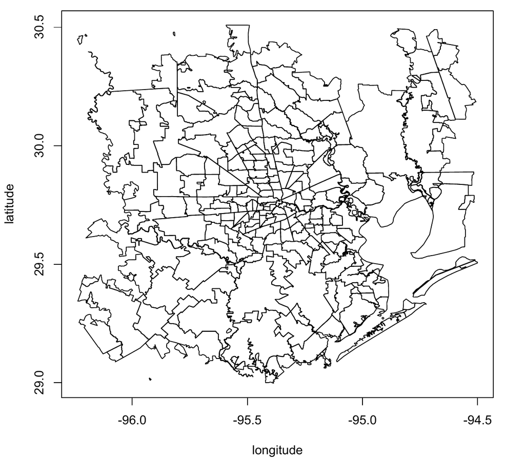

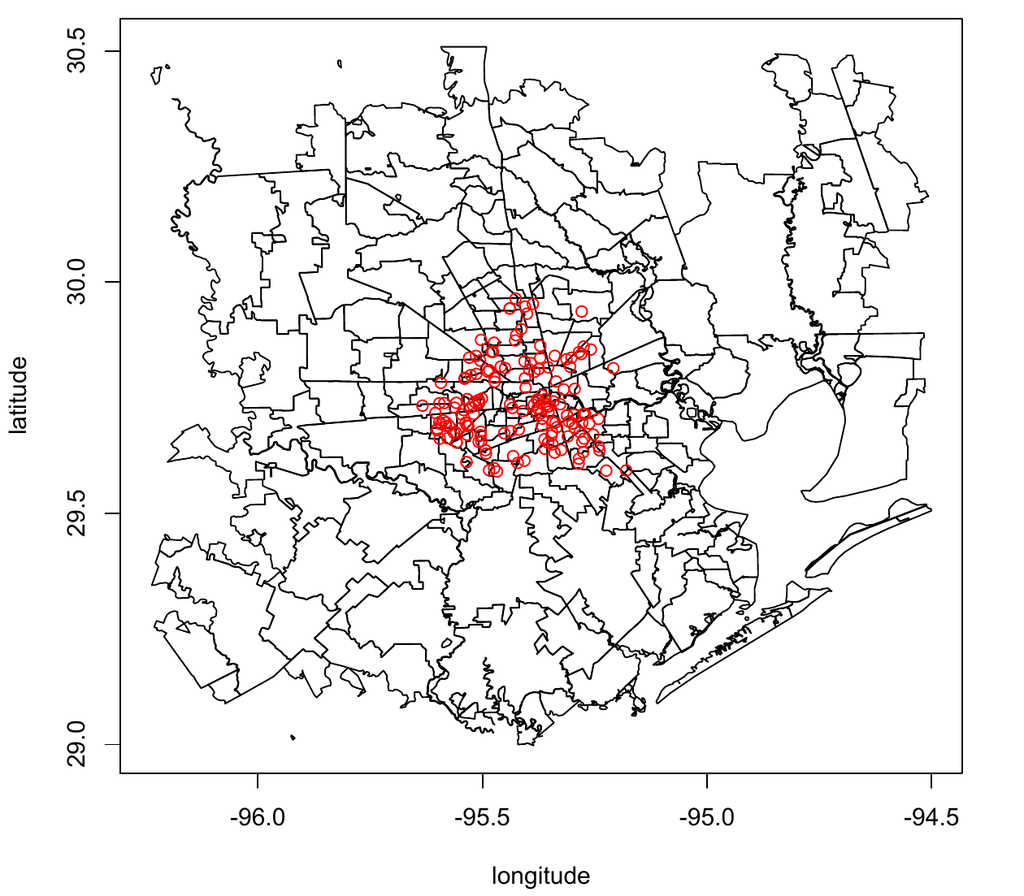

Figure 1: A typical R areal plot – zip codes in the Greater Houston area (left), and a typical R spatial scatterplot – murders in Houston from January 2010 to August 2010 (right).

While these kinds of plots are useful, they are not as informative as we would like in many situations. For instance, when plotting zip codes it is helpful to also see major roads and other landmarks which form the boundaries of areal units.

The situation for point referenced spatial data is often much worse. Since we can’t easily contextualize a scatterplot of points without any background information at all, it is common to add points as an overlay of some areal data—whatever areal data is available. The resulting plot looks like Figure 1 (right).

In most cases the plot is understandable to the researcher who has worked on the problem for some time but is of hardly any use to his audience, who must work to associate the data of interest with their location. Moreover, it leaves out many practical details—are most of the events to the east or west of landmark $x$? Are they clustered around more well-to-do parts of town, or do they tend to occur in disadvantaged areas? Questions like these can’t really be answered using these kinds of graphics because we don’t think in terms of small scale areal boundaries (e.g. zip codes or census tracts).

With a little effort better plots can be made, and tools such as [*maps*](https://CRAN.R-project.org/package=maps), [*maptools*](https://CRAN.R-project.org/package=maptools), *sp*, or *RgoogleMaps* make the process much easier; in fact, *RgoogleMaps* was the inspiration for *ggmap* (Becker et al. 2013; R. Bivand and Lewin-Koh 2013).

Moreover, there has recently been a deluge of interest in the subject of mapmaking in R—Ian Fellows’ excellent interactive GUI-driven [*DeducerSpatial*](https://CRAN.R-project.org/package=DeducerSpatial) package based on Bing Maps comes to mind (Fellows, Rickett, and Fultz 2013). *ggmap* takes another step in this direction by situating the contextual information of various kinds of static maps in the *ggplot2* plotting framework. The result is an easy, consistent way of specifying plots which are readily interpretable by both expert and audience and safeguarded from graphical inconsistencies by the layered grammar of graphics framework. The result is a spatial plot resembling Figure 2. Note that map images and information in this work may appear slightly different due to map provider changes over time.

[figure not shown]

Figure 2: A spatial scatterplot based on Stamen Maps’ terrain tile set made with the qmplot function, an experimental amalgamation of the functions presented in this article.

```r
murder <- subset(crime, offense == "murder")
qmplot(lon, lat, data = murder, colour = I('red'), size = I(3), darken = .3)
```

# The layered grammar of graphics

One advantage of making the plots with *ggplot2* is the layered grammar of graphics on which *ggplot2* is based (H. Wickham 2010; Wilkinson 2005). By definition, the layered grammar demands that every plot consist of five components :

- a default dataset with aesthetic mappings,
- one or more layers, each with a geometric object (“geom”), a statistical transformation (“stat”), and a dataset with aesthetic mappings (possibly defaulted),
- a scale for each aesthetic mapping (which can be automatically generated),
- a coordinate system, and
- a facet specification.

Since *ggplot2* is an implementation of the layered grammar of graphics, every plot made with *ggplot2* has each of the above elements. Consequently, *ggmap* plots also have these elements, but certain elements are fixed to map components : the $x$ aesthetic is fixed to longitude, the $y$ aesthetic is fixed to latitude, and the coordinate system is fixed to the Mercator projection.[^1]

The major theoretical advantage of using the layered grammar in plotting maps is that aesthetic scales are kept consistent. In the typical situation where the map covers the extent of the data, in *ggmap* the latitude and longitude scales key off the map (by default) and one scale is used for those axes. The same is true of colors, fills, alpha blendings, and other aesthetics which are built on top of the map when other layers are presented—each is allotted one scale which is kept consistent across each layer of the plot. This aspect of the grammar is particularly important for faceted plots in order to make a proper comparison across several plots. Of course, the scales can still be tricked if the user improperly specifies the spatial data, e.g. using more than one projection in the same map, but fixing such errors is beyond any framework.

The practical advantage of using the grammar is even better. Since the graphics are done in *ggplot2* the user can draw from the full range of *ggplot2*’s capabilities to layer elegant visual content—geoms, stats, scales, etc.—using the usual *ggplot2* coding conventions. This was already seen briefly in Figure 2 where the arguments of `qmplot` are identical to that of *ggplot2*’s `qplot`; much more will be seen shortly.

# How *ggmap* works

The basic idea driving *ggmap* is to take a downloaded map image, plot it as a context layer using *ggplot2*, and then plot additional content layers of data, statistics, or models on top of the map. In *ggmap* this process is broken into two pieces – (1) downloading the images and formatting them for plotting, done with `get_map`, and (2) making the plot, done with `ggmap`. `qmap` marries these two functions for quick map plotting (c.f. *ggplot2*’s `ggplot`), and `qmplot` attempts to wrap up the entire plotting process into one simple command (c.f. *ggplot2*’s `qplot`).

## The `get_map` function

In *ggmap*, downloading a map as an image and formatting the image for plotting is done with the `get_map` function. More specifically, `get_map` is a wrapper function for the underlying functions `get_googlemap`, `get_openstreetmap`, `get_stamenmap`, and `get_cloudmademap` which accepts a wide array of arguments and returns a classed raster object for plotting with `ggmap`.

As the most important characteristic of any map is location, the most important argument of `get_map` is the `location` argument. Ideally, `location` is a longitude/latitude pair specifying the center of the map and accompanied by a `zoom` argument, an integer from 3 to 20 specifying how large the spatial extent should be around the center, with 3 being the continent level and 20 being roughly the single building level. `location` is defaulted to downtown Houston, Texas, and `zoom` to 10, roughly a city-scale.

While longitude/latitude pairs are ideal for specifying a location, they are somewhat inconvenient on a practical level. For this reason, `location` also accepts a character string. The string, whether containing an address, zip code, or proper name, is then passed to the `geocode` function which then determines the appropriate longitude/latitude coordinate for the center. In other words, there is no need to know the exact longitude/latitude coordinates of the center of the map—`get_map` can determine them from more colloquial (“lazy”) specifications so that they can be specified very loosely. For example, since

```r
> geocode("the white house")
      lon       lat
-77.03676  38.89784
```

works, `"the white house"` is a viable `location` argument. More details on `geocode` and other utility functions are discussed at the end of this article.

In lieu of a center/zoom specification, some users find a bounding box specification more convenient. To accommodate this form of specification, `location` also accepts numeric vectors of length four following the left/bottom/right/top convention. This option is not currently available for Google Maps.

While each map source has its own web application programming interface (API), specification of `location`/`zoom` in `get_map` works for each by computing the appropriate parameters (if necessary) and passing them to each of the API specific `get_*` functions. To ensure that the resulting maps are the same across the various sources for the same `location`/`zoom` specification, `get_map` first grabs the appropriate Google Map, determines its bounding box, and then downloads the other map as needed. In the case of Stamen Maps and CloudMade Maps, this involves a stitching process of combining several tiles (small map images) and then cropping the result to the appropriate bounding box. The result is a single, consistent specification syntax across the four map sources as seen for Google Maps and OpenStreetMap in Figure 3.

```r
baylor <- "baylor university"
qmap(baylor, zoom = 14)
```

[figure not shown]

```r
qmap(baylor, zoom = 14, source = "osm")
```

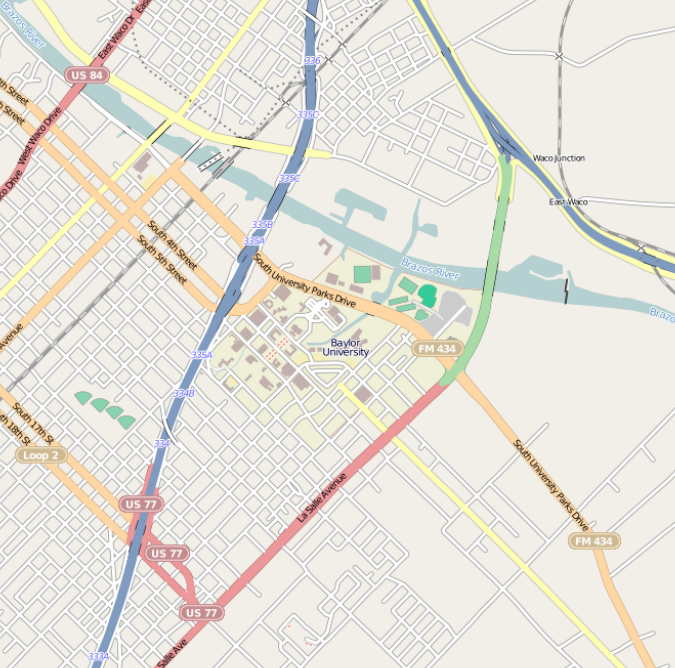

Figure 3: get_map provides the same spatial extent for Google Maps (top) and OpenStreetMaps (bottom) with a single simple syntax, even though their APIs are quite different.

Before moving into the `source` and `maptype` arguments, it is important to note that the underlying API specific `get_*` functions for which `get_map` is a wrapper provide more extensive mechanisms for downloading from their respective sources. For example, `get_googlemap` can access almost the full range of the Google Static Maps API as seen in Figure 4.

[figure not shown]

Figure 4: Accessing Google Maps API features with get_googlemap.

```r
set.seed(500)
df <- round(data.frame(
  x = jitter(rep(-95.36, 50), amount = .3),
  y = jitter(rep( 29.76, 50), amount = .3)
), digits = 2)

map <- get_googlemap('houston', markers = df, path = df, scale = 2)

ggmap(map, extent = 'device')
```

### Tile style – the `source` and `maptype` arguments of `get_map`

The most attractive aspect of using different map sources (Google Maps, OpenStreetMap, Stamen Maps, and CloudMade Maps) is the different map styles provided by the producer. These are specified with the `maptype` argument of `get_map` and must agree with the `source` argument. Some styles emphasize large roadways, others bodies of water, and still others political boundaries. Some are better for plotting in a black-and-white medium; others are simply nice to look at. This section gives a run down of the various map styles available in *ggmap*.

Google provides four different familiar types—terrain (default), satellite (e.g. Figure 13), roadmap, and hybrid (e.g. Figure 12). OpenStreetMap, on the other hand, only provides the default style shown in Figure 3.

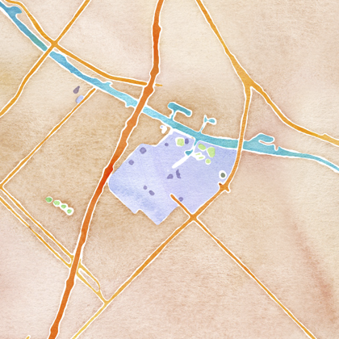

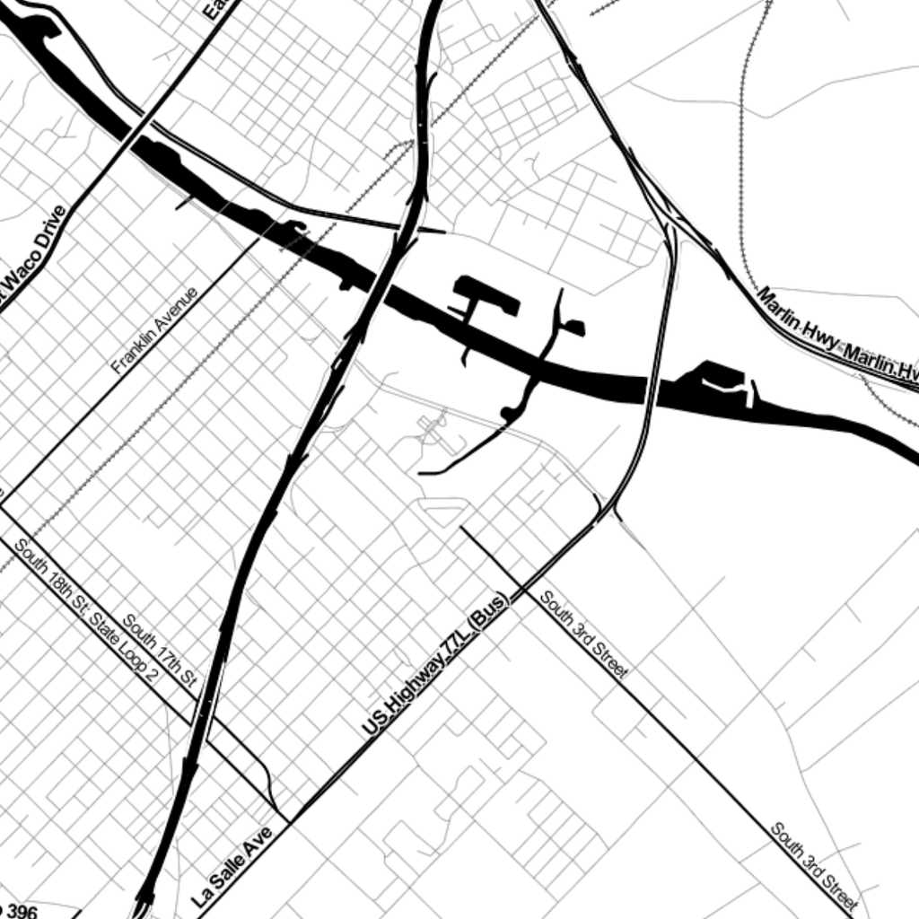

Figure 5: Stamen tile sets maptype = “watercolor” and maptype = “toner”.

```r
qmap(baylor, zoom = 14, source = "stamen", maptype = "watercolor")
qmap(baylor, zoom = 14, source = "stamen", maptype = "toner")
```

Stamen’s terrain tile set is quite similar to Google’s, but obviously the watercolor and toner tile sets are substantially different than any of the four Google tile sets. The latter, for example, is ideal for black-and-white plotting.

Both Stamen Maps and CloudMade Maps are built using OpenStreetMap data. These data are contributed by an open community of online users in much the same way Wikipedia is—both are free, both are user-contributed, and both are easily edited. Moreover, OpenStreetMap has data not only on roadways and bodies of water but also individual buildings, fountains, stop signs and other apparent minutiae. The drawback is that (like Google Maps) not all locations are mapped with the same degree of precision, and imperfections may be observed in small-scale out of the way features.[^2]

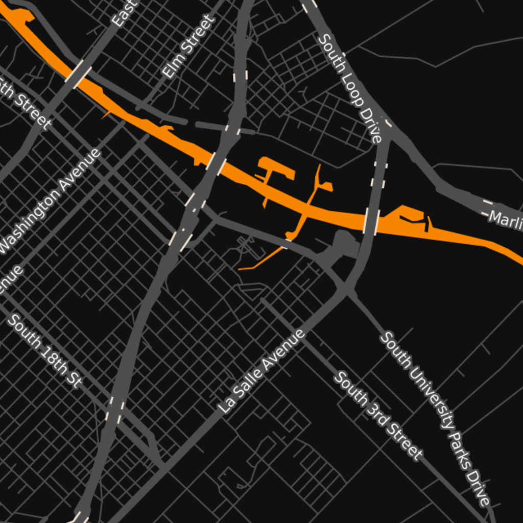

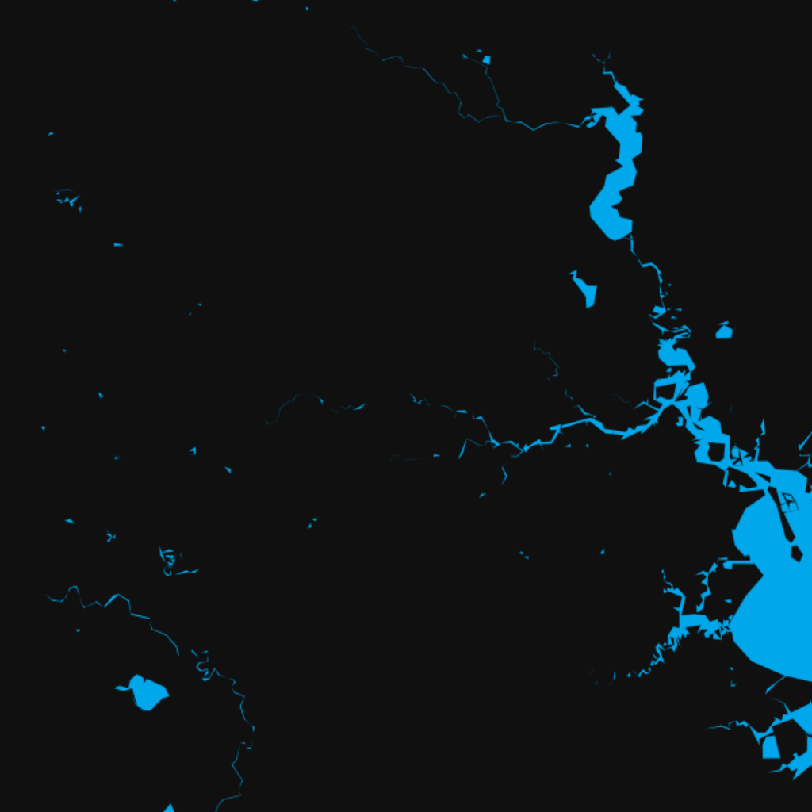

Figure 6: Two out of thousands of user made CloudMade Maps styles. The left is comparable to Figures 3 and 5, and the right contains the bodies of water in Figure 4.

```r
qmap(baylor, zoom = 14, maptype = 53428, api_key = api_key,
     source = "cloudmade")
qmap("houston", zoom = 10, maptype = 58916, api_key = api_key,
     source = "cloudmade")
```

## The `ggmap` function

Once `get_map` has grabbed the map of interest, `ggmap` is ready to plot it. The result of `get_map` is a specially classed raster object (a matrix of colors as hexadecimal character strings) –

```r
> paris <- get_map(location = "paris")
> str(paris)
 chr [1:1280, 1:1280] "#C6DAB6" "#C2D6B3" "#C2D6B3" ...
 - attr(*, "class")= chr [1:2] "ggmap" "raster"
 - attr(*, "bb")='data.frame':  1 obs. of  4 variables:
  ..$ ll.lat: num 48.6
  ..$ ll.lon: num 1.91
  ..$ ur.lat: num 49.1
  ..$ ur.lon: num 2.79
```

The purpose of `ggmap` is to take the map from the raster object to the screen, and it fulfills this purpose by creating a ggplot object which, when printed, draws the desired map in the graphics device. This is illustrated in Figure 7.

While `ggmap` requires a ggmap object, it accepts a handful of other arguments as well—`extent`, `base_layer`, `maprange`, `legend`, `padding`, and `darken`. With none of these additional arguments, `ggmap` effectively returns the following ggplot object

```r
ggplot(aes(x = lon, y = lat), data = fourCorners) +
  geom_blank() + coord_map("mercator") +
  annotation_raster(ggmap, xmin, xmax, ymin, ymax)
```

where `fourCorners` is the data frame resulting from applying `expand.grid` to the longitude and latitude ranges specified in the `bb` attribute of the ggmap object. Thus, the default base layer of the ggplot2 object created by `ggmap` is `ggplot(aes(x = lon, y = lat), data = fourCorners)`, and the default $x$ and $y$ aesthetic scales are calculated based on the longitude and latitude ranges of the map.

```r
ggmap(paris, extent = "normal")
```

[figure not shown]

Figure 7: Setting extent = “normal” in ggmap illustrates how maps in ggmap are simply ggplot2 graphics.

The `extent` argument dictates how much of the graphics device is covered by the map. It accepts three possible strings: `"normal"` shown in Figure 7, `"panel"` shown in Figures 10 and 12, and `"device"` shown in every other figure. `"normal"` situates the map with the usual axis padding provided by *ggplot2* and, consequently, one can see the panel behind it. `"panel"` eliminates this, setting the limits of the plot panel to be the longitude and latitude extents of the map with `scale_[x,y]_continuous(expand = c(0,0))`. `"device"` takes this to the extreme by eliminating the axes themselves with the new exported `theme_nothing`.

`base_layer` is a call which substitutes the default base layer to the user’s specification. Thus, in the above code the user can change `ggplot(aes(x = lon, y = lat), data = fourCorners)` to a different call. This is essential for faceting plots since the referent of *ggplot2* functions `facet_wrap` and `facet_grid` is the base layer. Since changing the base layer changes the base scales and therefore limits of the plot, it is possible that when the base layer is changed only part of the map is visible. Setting the `maprange` argument to `TRUE` (it defaults to `FALSE`) ensures that *the map* determines the $x$ and $y$ axis limits (longitude and latitude) via the `bb` attribute of the ggmap object itself, and not the `base_layer` argument.

The legend-related arguments of `ggmap` are `legend` and `padding`, and they are only applicable when `extent = "device"`. The `legend` argument determines where a legend should be drawn on the map if one should be drawn. Its options are `"left"`, `"right"` (default), `"bottom"`, `"top"`, `"topleft"`, `"bottomleft"`, `"topright"`, `"bottomright"` and `"none"`. The first four draw the legend according to *ggplot2*’s normal specifications (without any axes); the next four draw the legend on top of the map itself similar to ArcGIS; and the last eliminates the legend altogether. `padding` governs how far from the corner the legend should be drawn.

The `darken` argument, a suggestion by Jean-Olivier Irisson, tints the map image. The default, `c(0, "black")`, indicates a fully translucent black layer, i.e. no tint at all. Generally, the first argument corresponds to an alpha blending (0 = invisible, 1 = opaque) and the second argument the color of the tint. If only a number is supplied to the `darken` argument `ggmap` assumes a black tint. The tint itself is made by adding a `geom_rect` layer on top of the map. An example is provided by Figure 2, where a black tint was added to the map to enhance the visibility of the points.

Since `ggmap` returns a ggplot object, the product of `ggmap` can itself act as a base layer in the *ggplot2* framework. This is an incredibly important realization which allows for the full range of *ggplot2* capabilities. We now illustrate many of the ways in which this can be done effectively through a case study of violent crime in downtown Houston, Texas.

# *ggmap* in action

## Data

Crime data were compiled from the [Houston Police Department’s website](http://www.houstontx.gov/police/cs/stats2.htm) over the period of January 2010–August 2010. The data were lightly cleaned and aggregated using [*plyr*](https://CRAN.R-project.org/package=plyr) (Hadley Wickham 2011) and geocoded using Google Maps (to the center of the block, e.g., 6150 Main St.); the full data set is available in *ggmap* as the data set `crime`.

```r
> str(crime)
'data.frame':   86314 obs. of  17 variables:
 $ time    : POSIXt, format: "2010-01-01 0...
 $ date    : chr  "1/1/2010" "1/1/2010" "1...
 $ hour    : int  0 0 0 0 0 0 0 0 0 0 ...
 $ premise : chr  "18A" "13R" "20R" "20R" ...
 $ offense : chr  "murder" "robbery" "aggr...
 $ beat    : chr  "15E30" "13D10" "16E20" ...
 $ block   : chr  "9600-9699" "4700-4799" ...
 $ street  : chr  "marlive" "telephone" "w...
 $ type    : chr  "ln" "rd" "ln" "st" ...
 $ suffix  : chr  "-" "-" "-" "-" ...
 $ number  : int  1 1 1 1 1 1 1 1 1 1 ...
 $ month   : Factor w/ 12 levels "january"...
 $ day     : Factor w/ 7 levels "monday"  ...
 $ location: chr  "apartment parking lot" ...
 $ address : chr  "9650 marlive ln" "4750 ...
 $ lon     : num  -95.4 -95.3 -95.5 -95.4 ...
 $ lat     : num  29.7 29.7 29.6 29.8 29.7...
```

Since we are only interested in violent crimes which take place downtown, we restrict the data set to those qualifiers. To determine a bounding box, we first use `gglocator`, a *ggplot2* analogue of base’s `locator` function exported from *ggmap*. `gglocator` works not only for *ggmap* plots, but *ggplot2* graphics in general.

```r
> # find a reasonable spatial extent
> qmap('houston', zoom = 13)
> gglocator(2)
>         lon      lat
> 1 -95.39681 29.78400
> 2 -95.34188 29.73631
>
> # only violent crimes
> violent_crimes <- subset(crime,
+   offense != "auto theft" & offense != "theft" & offense != "burglary")
>
> # order violent crimes
> violent_crimes$offense <- factor(violent_crimes$offense,
+   levels = c("robbery", "aggravated assault", "rape", "murder"))
>
> # restrict to downtown
> violent_crimes <- subset(violent_crimes,
+   -95.39681 <= lon & lon <= -95.34188 &
+    29.73631 <= lat & lat <=  29.78400)
```

The analysis performed only concerns data on the violent crimes of aggravated assault, robbery, rape and murder. Note that while some effort was made to ensure the quality of the data, the data were only leisurely cleaned and the data set may still contain errors.

## Analysis

The first step we might want to take is to look at where the individual crimes took place. Modulo some simple *ggplot2* styling changes (primarily in the fonts and key-styles of the legends via *ggplot2*’s `guide` function), Figure 8 contains the code to produce the spatial bubble chart shown on the left.

One of the problems with the bubble chart is overplotting and point size—we can’t really get a feel for what crimes are taking place and where. One way around this is to bin the points and drop the bins which don’t have any samples in them. The result (Figure 8 right) shows us where the crimes are happening at the expense of knowing their frequency.

The binned plot is the first time we really begin to see the power of having the maps in the *ggplot2* framework. While it is actually not a very good plot, it illustrates the practical advantage of the *ggplot2* framework with the contextual information of the map—the process of splitting the data frame `violent_crimes` into chunks based on the offense variable, binning the points of each, and aggregating back into one data set to plot is all done entirely behind the scenes by *ggplot2*.

[figure not shown]

[figure not shown]

Figure 8: Violent crime bubble chart of downtown Houston (left) and the same binned (right).

```r
theme_set(theme_bw(16))
HoustonMap <- qmap("houston", zoom = 14, color = "bw", legend = "topleft")

HoustonMap +
   geom_point(aes(x = lon, y = lat, colour = offense, size = offense),
              data = violent_crimes)

HoustonMap +
  stat_bin2d(
    aes(x = lon, y = lat, colour = offense, fill = offense),
    size = .5, bins = 30, alpha = 1/2,
    data = violent_crimes
  )
```

What about violent crimes in general? If we neglect the type of offense, we can get a good idea of the spatial distribution of violent crimes by using a contour plot. Since the map image itself is based on *ggplot2*’s `annotation_raster`, which doesn’t have a fill aesthetic, we can access the fill aesthetic to make a filled contour plot. This is seen in Figure 9 (left).

[figure not shown]

[figure not shown]

Figure 9: Filled contour plot of violent crimes (left), and the same with an inset (right).

```r
houston <- get_map("houston", zoom = 14)
HoustonMap <- ggmap("houston", extent = "device", legend = "topleft")

HoustonMap +
  stat_density2d(
    aes(x = lon, y = lat, fill = ..level..,  alpha = ..level..),
    size = 2, bins = 4, data = violent_crimes,
    geom = "polygon"
  )

overlay <- stat_density2d(
  aes(x = lon, y = lat, fill = ..level.., alpha = ..level..),
  bins = 4, geom = "polygon",
  data = violent_crimes
)

HoustonMap + overlay + inset(
    grob = ggplotGrob(ggplot() + overlay + theme_inset()),
    xmin = -95.35836, xmax = Inf, ymin = -Inf, ymax = 29.75062
  )
```

These kinds of overlays can be incredibly effective; however, their ability to communicate information can be hindered by the fact that the map overlay can be visually confused with the map itself. This is particularly common when using colored maps. To get around this problem the `inset` function can be used to insert map insets containing the overlay on a white background with major and minor axes lines for visual guides made possible by the exported function `theme_inset`; this is seen in Figure 9 (right).

The image indicates that there are three main hotspots of activity. Each of these three corresponds to locations commonly held by Houstonians to be particularly dangerous locations. From east to west, the hotspots are caused by (1) a county jail which releases its inmates twice daily, who tend to loiter in the area indicated, (2) a commercial bus station in an area of substantial homelessness and destitution, and (3) a prostitution hotspot in a very diverse and pedestrian part of town.

In addition to single plots, the `base_layer` argument to `ggmap` or `qmap` allows for faceted plots (see Figure 10). This is particularly useful for spatiotemporal data with discrete temporal components (day, month, season, year, etc.).

This last plot displays one of the known issues with contour plots in *ggplot2*—a “clipping” or “tearing” of the contours. Aside from that fact (which will likely be fixed in subsequent *ggplot2* versions), we can see that in fact most violent crimes happen on Monday, with a distant second being Friday. Friday’s pattern is easily recognizable—a small elevated dot in the downtown bar district and an expanded region to the southwest in the district known as midtown, which has an active nightlife. Monday’s pattern is not as easily explainable.

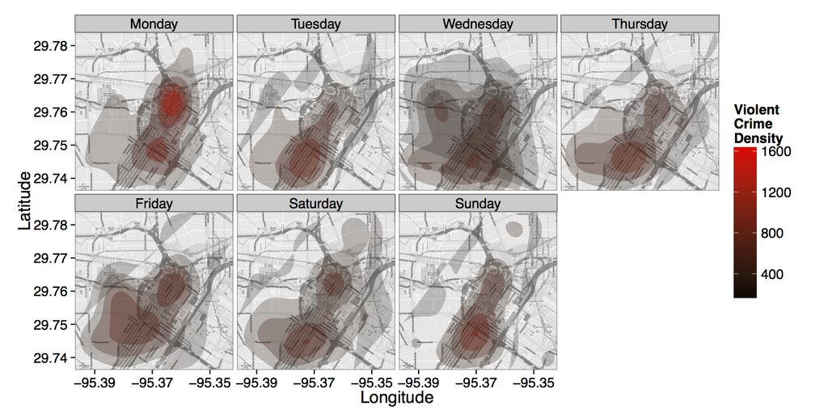

Figure 10: Faceted filled contour plot by day.

```r
houston <- get_map(location = "houston", zoom = 14, color = "bw",
                   source = "osm")

HoustonMap <- ggmap(houston, base_layer = ggplot(aes(x = lon, y = lat),
                    data = violent_crimes))

HoustonMap +
  stat_density2d(aes(x = lon, y = lat, fill = ..level.., alpha = ..level..),
    bins = 5, geom = "polygon",
    data = violent_crimes) +
  scale_fill_gradient(low = "black", high = "red") +
  facet_wrap(~ day)
```

# *ggmap*’s utility functions

*ggmap* has several utility functions which aid in spatial exploratory data analysis.

### The `geocode` function

The ability to move from an address to a longitude/latitude coordinate is virtually a must for visualizing spatial data. Unfortunately however, the process is almost always done outside R by using a proper geographic information system (GIS), saving the results, and importing them into R. The `geocode` function simplifies this process to a single line in R.

`geocode` is a vectorized function which accepts character strings and returns a data frame of geographic information. In the default case of `output = "simple"`, only longitudes and latitudes are returned. These are actually Mercator projections of the ubiquitous unprojected 1984 world geodetic system (WGS84), a spheroidal earth model used by Google Maps. When `output` is set to `"more"`, a larger data frame is returned which provides much more Google Geocoding information on the query:

```r
> geocode("baylor university", output = "more")
        lon      lat       type     loctype        address    north    south     east
1 -97.11441 31.54872 university approximate [long address] 31.55823 31.53921 -97.0984
       west postal_code       country   administrative_area_level_2
1 -97.13042       76706 united states                      mclennan
  administrative_area_level_1 locality   street  streetNo point_of_interest
1                       texas     waco s 5th st      1311              <NA>
```

In particular, administrative bodies at various levels are reported. Going further, setting `output = "all"` returns the entire JavaScript Object Notation (JSON) object given by the Google Geocoding API parsed by [*rjson*](https://CRAN.R-project.org/package=rjson) (Couture-Beil 2013).

The Geocoding API has a number of request limitations in place to prevent abuse. An unspecified short-term rate limit is in place (see `mapdist` below) as well as a 24-hour limit of 2,500 requests. These are monitored to some extent by the hidden global variable `.GoogleGeocodeQueryCount` and exported function `geocodeQueryCheck`. `geocode` uses these to monitor its own progress and will either (1) slow its rate depending on usage or (2) throw an error if the query limit is exceeded. Note that `revgeocode` shares the same request pool and is monitored by the same variable and function. To learn more about the Google Geocoding, Distance Matrix, and Directions API usage regulations, see the websites listed in the bibliography.

### The `revgeocode` function

In some instances it is useful to convert longitude/latitude coordinates into a physical address. This is made possible (to the extent to which it is possible) with the `revgeocode` function which also relies on the Google Geocoding API.

```r
> gc <- geocode("baylor university")
> (gc <- as.numeric(gc))
[1] -97.11441  31.54872
> revgeocode(gc)
[1] "S 1st St, Baylor University, Waco, TX 76706, USA"
```

Like `geocode`, more output can be provided as well –

```r
> revgeocode(gc, output = "more")
        address     route     establishment  neighborhood locality
1 [long address] S 1st St Baylor University        Baylor     Waco
  administrative_area_level_2 administrative_area_level_1       country postal_code
1                    McLennan                       Texas United States       76706
```

Thus, in addition to the physical *where* of a reverse geocode (i.e., the address), `revgeocode` can report the *what* at various levels of granularity. Finally, an `output = "all"` option is available which returns the entire JSON object reported by Google.